# This is a notebook where I play around with the Python machine learning library `scikit-learn` and `pandas` library to try and differentiate between the albums of two of my favorite artists: Drake and Kanye West.

# Created by [Nurzhan Kanatzhanov](https://nurzhankanatzhanov.github.io/portfolio/).

### Standard word processing functions to tokenize and process text

```python
import math, re
import glob, os
import pandas as pd
from collections import Counter

def tokenize(s):
    """
    Input:
        string s
    Output:
        list of strings
    """
    return s.split()

def preprocess(s, lowercase=True, strip_punctuation=True):
    """
    Input:
        string s
        boolean lowercase
        boolean strip_punctuation
    Return:
        list of strings
    """
    punctuation = '.,?<>:;"\'!%'
    if isinstance(s, str):
        s = tokenize(s)
    if lowercase:
        s = [t.lower() for t in s]
    if strip_punctuation:
        s = [t.strip(punctuation) for t in s]

    return s

def token_frequency(tokens=None, tf={}, relative=False):
    """
    Input:
        tokens = list of strings or None
        tf = dict or None
        relative = boolean
    Return:
        dictionary of token frequencies
    """
    for t in tokens:
        if t in tf:
            tf[t]+=1
        else:
            tf[t]=1
    if relative:
        total = sum([c for t, c in tf.items()])
        tf = {t:tf[t]/total for t in tf}
    return tf
```

### using `glob` module to retrieve files/pathnames of all .txt files (credit to [AZLyrics](https://azlyrics.com) for the lyrics of the artists)

```python
path = '/Users/nurzhan.kanatzhanov/Desktop/SP2020/Web Portfolio/portfolio/txt/*.txt'
filenames = glob.glob(path)
```

### setting the variable `TOP_N` to 20 to learn a model on the 20 most frequent words in each artists' album and using them as features (columns) in a pandas DataFrame

```python
TOP_N = 20

tf = {}
for fn in filenames:
    s = open(fn, 'r').read()
    tf = token_frequency(preprocess(s), tf=tf)

top_f = sorted(tf.items(), key=lambda x:x[1], reverse=True)[:TOP_N]

features = [t[0] for t in top_f]
```

### using the `os` library to split the filenames and give them proper titles to label each album nicely

### next, I calculate the relative frequencies of each word (token) in the album and save them in a dictionary, creating vectors for the `pandas DataFrame`

```python
labels = [os.path.split(fn)[1][:-4].replace('_', ' ').title() for fn in filenames]

vectors = [token_frequency(preprocess(open(f, 'r').read()), tf={}, relative=True) for f in filenames]

vectors = [{key:v[key] for key in v if key in features} for v in vectors]

vectors_df = pd.DataFrame(vectors, index=labels, columns=features).fillna(0)
```

### this is what a 20-feature, 17 album DataFrame looks like, with relative frequencies of each word in each album

```python
# remove truncation and adjust column width
pd.set_option('display.max_rows', None)
pd.set_option('display.max_columns', None)
pd.set_option('display.width', None)
pd.set_option('display.max_colwidth', -1)
vectors_df
```

|  | i | the | you | to | and | a | it | me | my | i'm | that | in | on | like | know | for | we | up | they | your |
| --- | --- | --- | --- | --- | --- | --- | --- | --- | --- | --- | --- | --- | --- | --- | --- | --- | --- | --- | --- | --- |
| Kanye My Beatiful Dark Twisted Fantasy | 0.036624 | 0.043570 | 0.029362 | 0.015049 | 0.019364 | 0.021995 | 0.011050 | 0.011682 | 0.012839 | 0.011261 | 0.008840 | 0.014944 | 0.005578 | 0.006104 | 0.009051 | 0.008630 | 0.007262 | 0.006104 | 0.005367 | 0.006630 |
| Drake Take Care | 0.036989 | 0.032581 | 0.045286 | 0.017285 | 0.022643 | 0.015038 | 0.018927 | 0.015556 | 0.008815 | 0.012791 | 0.017112 | 0.011235 | 0.008297 | 0.007864 | 0.012358 | 0.007692 | 0.007087 | 0.006568 | 0.010198 | 0.008297 |
| Kanye College Dropout | 0.039347 | 0.031830 | 0.022013 | 0.022703 | 0.025234 | 0.017794 | 0.010661 | 0.012272 | 0.015647 | 0.008360 | 0.011888 | 0.009511 | 0.008283 | 0.009587 | 0.006213 | 0.006443 | 0.006596 | 0.009434 | 0.004679 | 0.008360 |
| Drake Scorpion | 0.037743 | 0.030554 | 0.036844 | 0.020040 | 0.017344 | 0.015906 | 0.013839 | 0.023275 | 0.013659 | 0.010873 | 0.015007 | 0.008717 | 0.010784 | 0.008088 | 0.007728 | 0.014558 | 0.004134 | 0.006380 | 0.009795 | 0.008447 |
| Drake So Far Gone | 0.048596 | 0.031977 | 0.030258 | 0.019370 | 0.028539 | 0.019943 | 0.016504 | 0.010430 | 0.014900 | 0.021433 | 0.011117 | 0.012722 | 0.016619 | 0.007106 | 0.006418 | 0.005616 | 0.004928 | 0.006074 | 0.005616 | 0.006189 |
| Kanye Jesus Is King | 0.024240 | 0.061113 | 0.020826 | 0.014681 | 0.010584 | 0.013315 | 0.006487 | 0.010584 | 0.018436 | 0.007170 | 0.005463 | 0.009560 | 0.019802 | 0.008194 | 0.003073 | 0.006487 | 0.022875 | 0.007170 | 0.005463 | 0.008877 |
| Kanye Late Registration | 0.033267 | 0.037939 | 0.022029 | 0.020583 | 0.019137 | 0.016355 | 0.010236 | 0.012350 | 0.011682 | 0.009123 | 0.012239 | 0.009791 | 0.008011 | 0.007343 | 0.004673 | 0.006676 | 0.010570 | 0.006453 | 0.006453 | 0.005785 |
| Drake If Youre Reading This Its Too Late | 0.042807 | 0.033295 | 0.029118 | 0.018561 | 0.012645 | 0.021346 | 0.016821 | 0.014733 | 0.012529 | 0.022390 | 0.011485 | 0.011021 | 0.011717 | 0.009049 | 0.010093 | 0.007193 | 0.007541 | 0.009745 | 0.008701 | 0.004408 |
| Kanye Graduation | 0.042311 | 0.030783 | 0.030910 | 0.018115 | 0.021155 | 0.013935 | 0.012921 | 0.017102 | 0.013301 | 0.011274 | 0.008994 | 0.010008 | 0.008487 | 0.008741 | 0.007347 | 0.004180 | 0.007601 | 0.006714 | 0.005067 | 0.004687 |
| Kanye Ye | 0.050205 | 0.035680 | 0.030628 | 0.017998 | 0.013262 | 0.011683 | 0.015788 | 0.010104 | 0.011999 | 0.005684 | 0.013262 | 0.007262 | 0.014209 | 0.006315 | 0.010420 | 0.004105 | 0.006947 | 0.008525 | 0.008841 | 0.004736 |
| Drake More Life | 0.039446 | 0.029531 | 0.031023 | 0.026759 | 0.014072 | 0.018124 | 0.011834 | 0.018124 | 0.015032 | 0.014712 | 0.010021 | 0.007569 | 0.010448 | 0.010981 | 0.010341 | 0.007143 | 0.008742 | 0.010554 | 0.006716 | 0.006610 |
| Drake Nothing Was The Same | 0.044998 | 0.036020 | 0.029154 | 0.020703 | 0.015422 | 0.014471 | 0.025140 | 0.013415 | 0.012253 | 0.009295 | 0.014049 | 0.008873 | 0.013309 | 0.010140 | 0.008662 | 0.008556 | 0.008767 | 0.005915 | 0.004859 | 0.004753 |
| Kanye 808S & Heartbreak | 0.045489 | 0.031164 | 0.054034 | 0.019352 | 0.014828 | 0.011812 | 0.017090 | 0.010304 | 0.014074 | 0.013069 | 0.014577 | 0.011561 | 0.006534 | 0.007288 | 0.015330 | 0.003770 | 0.005529 | 0.003267 | 0.003770 | 0.009299 |
| Kanye Yeezus | 0.030827 | 0.038533 | 0.025689 | 0.017749 | 0.016581 | 0.021485 | 0.014012 | 0.012844 | 0.015180 | 0.014012 | 0.009809 | 0.021018 | 0.012377 | 0.006539 | 0.007940 | 0.003270 | 0.011443 | 0.008174 | 0.006305 | 0.011910 |
| Drake Views | 0.046472 | 0.023131 | 0.046895 | 0.024609 | 0.018166 | 0.022708 | 0.019434 | 0.021969 | 0.016265 | 0.011935 | 0.011301 | 0.009717 | 0.011829 | 0.013942 | 0.008344 | 0.009400 | 0.005703 | 0.005598 | 0.011301 | 0.006232 |
| Drake Thank Me Later | 0.044433 | 0.028781 | 0.034840 | 0.016789 | 0.018935 | 0.016662 | 0.018935 | 0.017420 | 0.009089 | 0.011613 | 0.015021 | 0.009215 | 0.007700 | 0.006564 | 0.007069 | 0.007574 | 0.005049 | 0.005933 | 0.007448 | 0.006943 |
| Kanye The Life Of Pablo | 0.046310 | 0.035860 | 0.025190 | 0.019030 | 0.012430 | 0.016280 | 0.010450 | 0.010890 | 0.014080 | 0.010670 | 0.009020 | 0.015070 | 0.007370 | 0.006600 | 0.007700 | 0.007920 | 0.009130 | 0.008030 | 0.005280 | 0.007590 |

### using `scikit-learn`'s `KMeans` to learn 2 clusters from the data

```python
from sklearn.cluster import KMeans

n_clusters = 2
kmeans = KMeans(n_clusters = n_clusters, random_state = 0).fit(vectors_df)
```

### projecting all 20 features onto a 2-dimensional space using `scikit-learn`'s principal component analysis [(PCA)](https://scikit-learn.org/stable/modules/generated/sklearn.decomposition.PCA.html).

```python
from sklearn.decomposition import PCA

pca = PCA(n_components=2)
transformed = pca.fit_transform(vectors_df)

x = transformed[:,0]
y = transformed[:,1]
```

### finally, using the `matplotlib` Python plotting library and an automatic label placement library `adjustText` [(link)](https://github.com/Phlya/adjustText) to make a scatter plot of the 17 albums on a 2D transformed space.

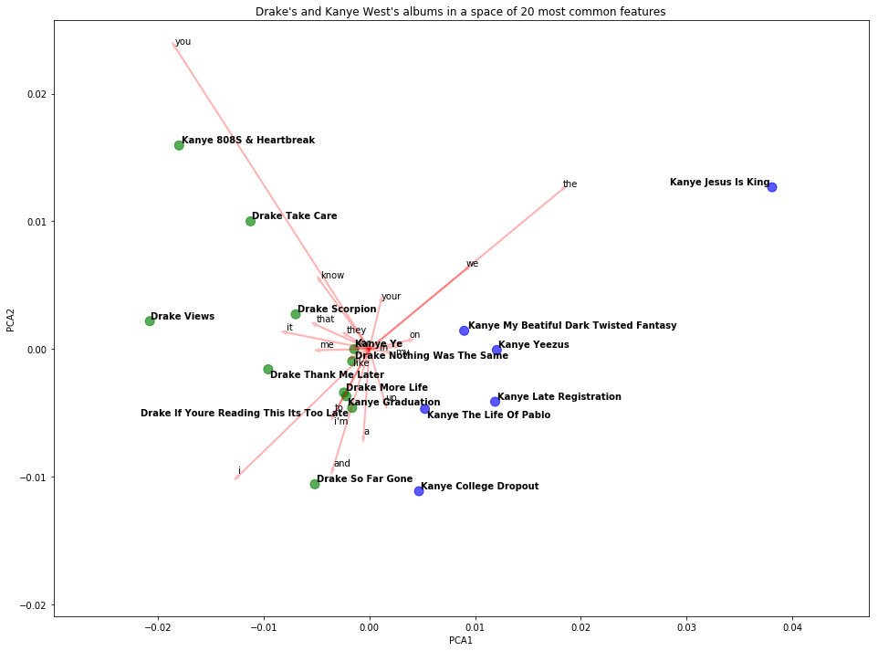

```python
import matplotlib.pyplot as plt
from adjustText import adjust_text

col_dict = {0:'green', 1:'blue'}
cols = [col_dict[l] for l in kmeans.labels_]
plt.figure(figsize=(16,12))
plt.scatter(x,y, c=cols, s=100, alpha=.65)
texts = []
for i, l in enumerate(labels):
    texts.append(plt.text(x[i],y[i], l, weight='bold'))
arrows = []
for i, c in enumerate(pca.components_.transpose()):
    plt.arrow(0,0, c[0]/30, c[1]/30, alpha=.2, width=.0001, color="red")
    arrows.append(plt.text(c[0]/30, c[1]/30, features[i]))
plt.xlabel('PCA1')
plt.ylabel('PCA2')
plt.title("Drake's and Kanye West's albums in a space of {} most common features".format(TOP_N))
adjust_text(texts)
adjust_text(arrows)
plt.show()
```

### as we see from the plot above, 6 out of 9 Kanye West albums got clustered together in blue (*Jesus is king*, *My Beautiful Dark Twisted Fantasy*, *Yeezus*, *Late Registration*, *The Life of Pablo*, and *College Dropout*). However, 3 of them (*808s & Hearbreak*, *Ye*, and *Graduation*) were clustered with Drake's albums. It is good to note that **all** of Drake's albums were clustered together (in green), showing common similarities in the rapper's word choice.

### Now, let's try something different. As expected in any text corpus, the most common features would be short stopwords like *you*, *the*, *it*, *I*, etc. Let's see what would happen if we try to **exclude** these words and play around with `gensim`, an unsupervised topic modeling and language processing library.

#### implementing a helper function that would filter out the stopwords

```python
def get_texts(filenames, stop_words):
    for fn in filenames:
        text = open(fn, 'r').read()
        text = [t for t in preprocess(text) if t not in stop_words]
        yield(text)
```

```python
NUM_TOPICS = 5
TOPN = 15
STOP = 100
```

### One of the strategies to get the stopwords is too find the 100 most frequent words

```python
freqs = {}
for file in filenames:
    freqs = token_frequency(preprocess(open(file, 'r').read()), tf=freqs)
stop_words = sorted(freqs, key=freqs.__getitem__, reverse=True)[:STOP]
```

### Make a `gensim Dictionary` first to map between words and their integer ID's, and then convert each document into the bag-of-words (BoW) format.

### Next, I use the `gensim` Latent Dirichlet Allocation (LDA) algorithm for topic modeling

```python
from gensim import corpora, models, similarities

dictionary = corpora.Dictionary(get_texts(filenames, stop_words))
corpus = [dictionary.doc2bow(text) for text in get_texts(filenames, stop_words)]
lda = models.LdaModel(corpus, id2word=dictionary, num_topics=NUM_TOPICS)

corpus_lda = lda[corpus]
```

### For visualization, this is what the top 15 words in each topic would be:

```python
for topic in range(NUM_TOPICS):
    tt = lda.get_topic_terms(topic, topn=TOPN)
    top_words = [dictionary[t] for t, w in tt]
    top_words = ', '.join(top_words)
    print('Topic {:>2d}: {}'.format(topic, top_words))
```

```
Topic  0: who, look, them, new, through, even, will, everything, real, em, think, come, did, always, god
Topic  1: why, look, things, money, think, where, or, thing, real, us, only, than, god, even, night
Topic  2: us, as, who, money, said, over, much, them, only, think, god, new, i'll, things, even
Topic  3: even, them, where, everything, over, us, think, mind, real, only, or, as, em, come, i'll
Topic  4: only, them, over, where, as, new, or, think, everything, us, money, always, i'll, said, night
```

### This is each albums distribution of topics by percentage:

```python
for i, label in enumerate(labels):
    topics = sorted(corpus_lda[i], key = lambda x:x[1], reverse=True)
    topics = ['Topic {} ({:2.2f}%)'.format(t[0], t[1]*100) for t in topics]
    topics = ', '.join(topics)
    print('{}:\n{}\n'.format(label, topics))
```

```
Kanye My Beatiful Dark Twisted Fantasy:
Topic 2 (68.28%), Topic 1 (28.41%), Topic 0 (3.30%)

Drake Take Care:
Topic 3 (87.61%), Topic 0 (6.78%), Topic 2 (3.89%), Topic 1 (1.70%)

Kanye College Dropout:
Topic 2 (70.80%), Topic 1 (24.85%), Topic 3 (2.46%), Topic 4 (1.89%)

Drake Scorpion:
Topic 3 (64.06%), Topic 0 (15.62%), Topic 1 (11.71%), Topic 2 (8.23%)

Drake So Far Gone:
Topic 1 (89.16%), Topic 3 (7.61%), Topic 4 (2.16%), Topic 0 (1.06%)

Kanye Jesus Is King:
Topic 2 (99.92%)

Kanye Late Registration:
Topic 3 (93.90%), Topic 0 (3.46%), Topic 1 (2.61%)

Drake If Youre Reading This Its Too Late:
Topic 1 (88.01%), Topic 3 (7.78%), Topic 0 (3.75%)

Kanye Graduation:
Topic 3 (62.37%), Topic 0 (20.73%), Topic 1 (16.89%)

Kanye Ye:
Topic 1 (99.11%)

Drake More Life:
Topic 0 (67.26%), Topic 1 (30.99%)

Drake Nothing Was The Same:
Topic 2 (77.77%), Topic 0 (20.26%), Topic 1 (1.95%)

Kanye 808S & Heartbreak:
Topic 0 (92.71%), Topic 1 (7.25%)

Kanye Yeezus:
Topic 3 (74.88%), Topic 1 (18.16%), Topic 0 (6.94%)

Drake Views:
Topic 1 (53.94%), Topic 3 (36.03%), Topic 2 (10.02%)

Drake Thank Me Later:
Topic 0 (64.11%), Topic 3 (35.36%)

Kanye The Life Of Pablo:
Topic 2 (57.53%), Topic 1 (23.70%), Topic 0 (11.88%), Topic 3 (6.89%)
```

### I am also going to use `gensim`'s similarities class that "computes similarities across a collection of documents in the Vector Space Model." This will connect the most similar albums between Drake and Kanye West.

```python
similarity_index = similarities.SparseMatrixSimilarity(corpus_lda, num_features=NUM_TOPICS)

print('Most similar texts:\n')
for i, label in enumerate(labels):
    sim = similarity_index[corpus_lda[i]]
    sim_labels = sorted(zip(sim, labels), reverse=True)
    sim_print = [l for s, l in sim_labels][1:4]
    sim_print = ', '.join(sim_print)
    print('{}: {}\n'.format(label, sim_print))
```

```
Most similar texts:

Kanye My Beatiful Dark Twisted Fantasy: Kanye College Dropout, Kanye The Life Of Pablo, Kanye Jesus Is King

Drake Take Care: Kanye Late Registration, Drake Scorpion, Kanye Yeezus

Kanye College Dropout: Kanye College Dropout, Kanye The Life Of Pablo, Kanye Jesus Is King

Drake Scorpion: Kanye Yeezus, Drake Take Care, Kanye Graduation

Drake So Far Gone: Drake If Youre Reading This Its Too Late, Kanye Ye, Drake Views

Kanye Jesus Is King: Drake Nothing Was The Same, Kanye My Beatiful Dark Twisted Fantasy, Kanye College Dropout

Kanye Late Registration: Drake Take Care, Kanye Yeezus, Drake Scorpion

Drake If Youre Reading This Its Too Late: Drake So Far Gone, Kanye Ye, Drake Views

Kanye Graduation: Drake Scorpion, Kanye Yeezus, Kanye Late Registration

Kanye Ye: Drake So Far Gone, Drake If Youre Reading This Its Too Late, Drake Views

Drake More Life: Kanye 808S & Heartbreak, Drake Thank Me Later, Drake If Youre Reading This Its Too Late

Drake Nothing Was The Same: Kanye Jesus Is King, Kanye My Beatiful Dark Twisted Fantasy, Kanye The Life Of Pablo

Kanye 808S & Heartbreak: Drake More Life, Drake Thank Me Later, Kanye Graduation

Kanye Yeezus: Drake Scorpion, Kanye Late Registration, Drake Take Care

Drake Views: Drake If Youre Reading This Its Too Late, Drake So Far Gone, Kanye Ye

Drake Thank Me Later: Kanye 808S & Heartbreak, Drake More Life, Kanye Graduation

Kanye The Life Of Pablo: Kanye My Beatiful Dark Twisted Fantasy, Kanye College Dropout, Drake Nothing Was The Same
```

### Let's visualize 25 most common words:

```
[2.0291578e-04 2.8627848e-05 2.8341370e-05 ... 2.7051228e-05 2.4993044e-05
 3.8262078e-05]
```

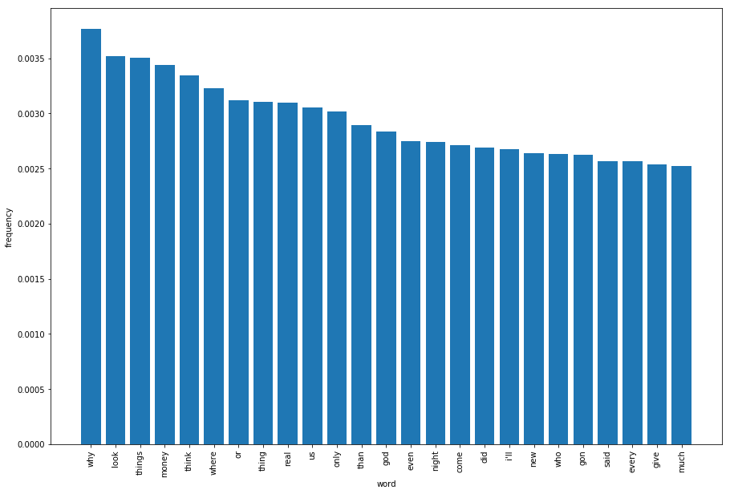

```python
import matplotlib.pyplot as plt

plt.figure(figsize=(15,10))
print(lda.get_topics()[0])
tokens, y = zip(*lda.get_topic_terms(1, topn=25))
tokens = [dictionary[t] for t in tokens]
x = list(range(25))
plt.bar(x,y, tick_label=tokens)
plt.xticks(rotation='vertical')
plt.xlabel('word')
plt.ylabel('frequency')
```

### Now, let's create vectors for the new `pandas` DataFrame with the distribution of topics of the 17 albums

```python
topics = list(range(NUM_TOPICS))
vectors = [{index:ratio for index, ratio in v} for v in corpus_lda]

vectors_df = pd.DataFrame(vectors, index=labels, columns=topics).fillna(0)
```

```python
n_clusters=2
kmeans = KMeans(n_clusters=n_clusters, random_state=0).fit(vectors_df)
kmeans.labels_
```

```
array([1, 0, 1, 0, 0, 1, 0, 0, 0, 0, 0, 1, 0, 0, 0, 0, 1], dtype=int32)
```

```python
pca = PCA(n_components=2)
transformed = pca.fit_transform(vectors_df)

x = transformed[:,0]
y = transformed[:,1]
```

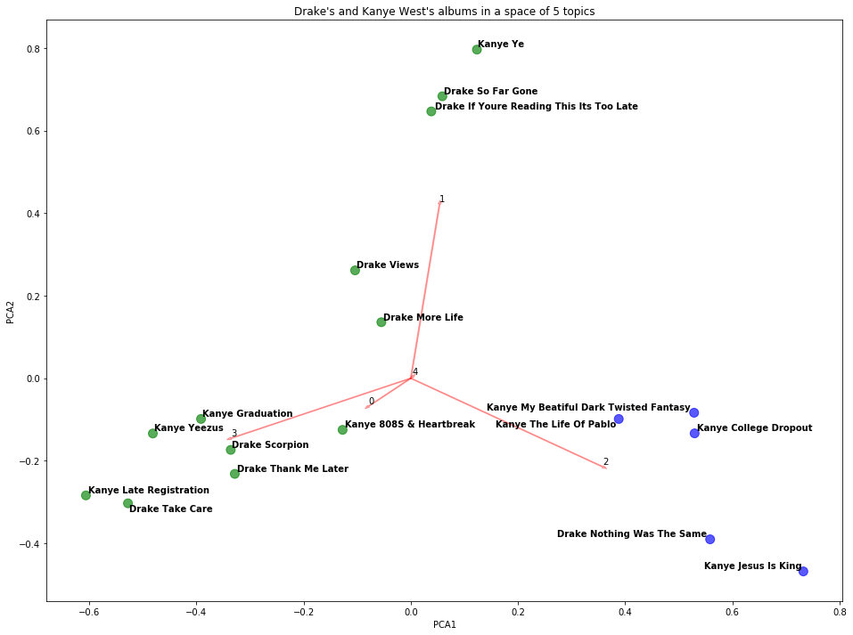

```python
col_dict = {0:'green', 1:'blue'}
cols = [col_dict[l] for l in kmeans.labels_]
plt.figure(figsize=(16,12))
plt.scatter(x,y, c=cols, s=100, alpha=.65)
texts = []
for i, l in enumerate(labels):
    texts.append(plt.text(x[i],y[i], l, weight='bold'))
arrows = []
for i, c in enumerate(pca.components_.transpose()):
    plt.arrow(0,0, c[0]/2, c[1]/2, alpha=.3, width=.002, color="red")
    arrows.append(plt.text(c[0]/2, c[1]/2, topics[i]))
plt.xlabel('PCA1')
plt.ylabel('PCA2')
plt.title("Drake's and Kanye West's albums in a space of {} topics".format(NUM_TOPICS))
adjust_text(texts)
adjust_text(arrows)
plt.show()
```

### Now, let's try something interesting: bring in another artist from a completely different genre of music. After some thought, I decided to include AC/DC, a hard rock band, to see how well the classification will work between different genres/styles of music.

```python
path_acdc = '/Users/nurzhan.kanatzhanov/Desktop/SP2020/Web Portfolio/portfolio/txt/acdc/*.txt'
filenames_acdc = glob.glob(path_acdc)
filenames_acdc.extend(filenames)
```

```python
NUM_TOPICS = 10

freqs = {}
for file in filenames_acdc:
    freqs = token_frequency(preprocess(open(file, 'r').read()), tf=freqs)
stop_words = sorted(freqs, key=freqs.__getitem__, reverse=True)[:STOP]

from gensim import corpora, models, similarities

dictionary = corpora.Dictionary(get_texts(filenames_acdc, stop_words))
corpus = [dictionary.doc2bow(text) for text in get_texts(filenames_acdc, stop_words)]
lda = models.LdaModel(corpus, id2word=dictionary, num_topics=NUM_TOPICS)

corpus_lda = lda[corpus]
```

```python
topics = list(range(NUM_TOPICS))
vectors = [{index:ratio for index, ratio in v} for v in corpus_lda]
labels = [os.path.split(fn)[1][:-4].replace('_', ' ').title() for fn in filenames_acdc]

vectors_df = pd.DataFrame(vectors, index=labels, columns=topics).fillna(0)
```

### Trying to cluster into 3 groups now

```python
n_clusters=3
kmeans = KMeans(n_clusters=n_clusters, random_state=0).fit(vectors_df)

pca = PCA(n_components=2)
transformed = pca.fit_transform(vectors_df)

x = transformed[:,0]
y = transformed[:,1]
```

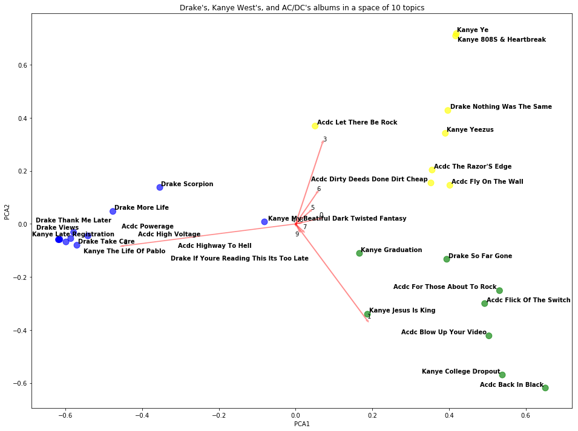

```python
col_dict = {0:'green', 1:'blue', 2:'yellow'}
cols = [col_dict[l] for l in kmeans.labels_]
plt.figure(figsize=(16,12))
plt.scatter(x,y, c=cols, s=100, alpha=.65)
texts = []
for i, l in enumerate(labels):
    texts.append(plt.text(x[i],y[i], l, weight='bold'))
arrows = []
for i, c in enumerate(pca.components_.transpose()):
    plt.arrow(0,0, c[0]/2, c[1]/2, alpha=.3, width=.002, color="red")
    arrows.append(plt.text(c[0]/2, c[1]/2, topics[i]))
plt.xlabel('PCA1')
plt.ylabel('PCA2')
plt.title("Drake's, Kanye West's, and AC/DC's albums in a space of {} topics".format(NUM_TOPICS))
adjust_text(texts)
adjust_text(arrows)
plt.show()
```

### Seems like the addition of AC/DC really does not show any key differences in topic modeling between AC/DC, Kanye West, and Drake!